# Reporting Engine dev tests

Pierre Chelle

2020-01-16

# Population Workflow

## Initialization of the population workflow

The initialization of the workflow defines:

1. A structured folder to save input, simulations and output (Fig 1).
2. A list of `tasks` to be performed during the run of the population workflow.
3. Settings for each of the `tasks`.

```r
popWorkflow <- PopulationWorkflow$new(
  simulationFile = "../data/S1.pkml",
  populationFile = "../data/pop_10.csv"
)
```

### 1. Output folder and structure

The expected output structure is represented in Fig 1. The default name of the folder is `Workflow<Current Date>`, this name can be overwritten in the initialization if input (`workflowFolder = ...`). Within each folder, 4 subfolders are created to stored specific pieces of the workflow.

- `Inputs` stores the input `population`, `simulation` and if necessary `observed data`.
- `Simulations` stores the results of the population simulations performed from the input.
- `Sensitivities` stores the results of the sensitivity analysis ? (Let me know what is the expected format)
- `Outputs` stores the output plot and table results.

The previous example created such a structure:

| Current Folder Structure |
| --- |
| . |
| ./Workflow2020-01-16 |
| ./Workflow2020-01-16/Inputs |
| ./Workflow2020-01-16/Outputs |
| ./Workflow2020-01-16/Sensitivities |
| ./Workflow2020-01-16/Simulations |

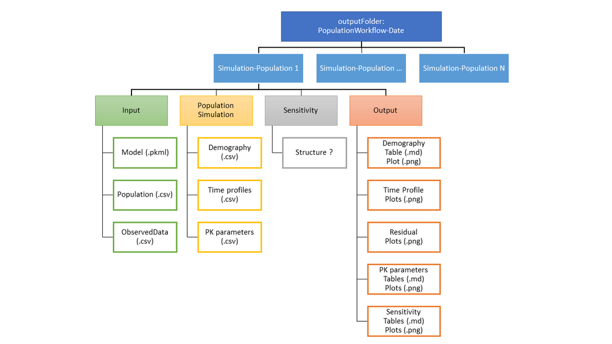

Fig 1: Expected structure of population workflow output

### 2. List of tasks

Once created, the `PopulationWorkflow` object contains a list of tasks to be performed. The `print()` method of the class allows the user to get the full structure of the tasks, their input, output and if the task should be run.

```r
popWorkflow$print()
```

```
## $`Task 1`
## $`Task 1`$task
## [1] "Simulate population"
##
## $`Task 1`$active
## [1] TRUE
##
## $`Task 1`$input
##                             population
## "Workflow2020-01-16/Inputs/pop_10.csv"
##                             simulation
##    "Workflow2020-01-16/Inputs/S1.pkml"
##
## $`Task 1`$output
##                                        populationSimulation
## "Workflow2020-01-16/Simulations/populationSimulation.RData"
##
##
## $`Task 2`
## $`Task 2`$task
## [1] "Calculate PK parameters"
##
## $`Task 2`$active
## [1] TRUE
##
## $`Task 2`$input
## list()
##
## $`Task 2`$output
## list()
##
##
## $`Task 3`
## $`Task 3`$task
## [1] "Analyze sensitivity"
##
## $`Task 3`$active
## [1] TRUE
##
## $`Task 3`$input
```

[output cut: 63 more lines]

```
##
## $`Task 7`
## $`Task 7`$task
## [1] "Plot sensitivity analysis"
##
## $`Task 7`$active
## [1] TRUE
##
## $`Task 7`$input
##                                          sensitivityAnalysis
## "Workflow2020-01-16/Sensitivities/sensitivityAnalysis.RData"
##
## $`Task 7`$output
##                                  sensitivityPlot
## "Workflow2020-01-16/Outputs/sensitivityPlot.png"
```

For example, the task `demographyPlot` of the Population Workflow can be verified by printing it:

```r
popWorkflow$demographyPlot$print()
```

```
## $task
## [1] "Plot demography"
##
## $active
## [1] TRUE
##
## $input
##                             population
## "Workflow2020-01-16/Inputs/pop_10.csv"
##                             simulation
##    "Workflow2020-01-16/Inputs/S1.pkml"
##
## $output
##                                 demographyResults
## "Workflow2020-01-16/Simulations/demography.RData"
##                                    demographyPlot
##       "Workflow2020-01-16/Outputs/demographyPlot"
##                                   demographyTable
##   "Workflow2020-01-16/Outputs/demographyTable.md"
```

It is possible to modify the fields of the tasks either using the method `set()`, or directly modifying the value of the field itself (however, the latter is unadvised). The methods `activate()` and `inactivate()` can be used for changing the value of the logical field `active`:

```r
popWorkflow$gofPlot$print()
```

```
## $task
## [1] "Plot goodness of fit diagnostics"
##
## $active
## [1] TRUE
##
## $input
##                                                  population
##                      "Workflow2020-01-16/Inputs/pop_10.csv"
##                                        populationSimulation
## "Workflow2020-01-16/Simulations/populationSimulation.RData"
##
## $output
##                                        gofResults
## "Workflow2020-01-16/Simulations/gofResults.RData"
##                                           gofPlot
##              "Workflow2020-01-16/Outputs/gofPlot"
```

```r
popWorkflow$gofPlot$inactivate()
popWorkflow$gofPlot$print()
```

```
## $task
## [1] "Plot goodness of fit diagnostics"
##
## $active
## [1] FALSE
##
## $input
##                                                  population
##                      "Workflow2020-01-16/Inputs/pop_10.csv"
##                                        populationSimulation
## "Workflow2020-01-16/Simulations/populationSimulation.RData"
##
## $output
##                                        gofResults
## "Workflow2020-01-16/Simulations/gofResults.RData"
##                                           gofPlot
##              "Workflow2020-01-16/Outputs/gofPlot"
```

## Run the tasks of the Population Workflow

Running all the active tasks of the workflow is possible using the method `runWorkflow()`. At the start of the worklow, general information about the workflow are printed and can be saved within a logfile.

```r
popWorkflow$runWorkflow()
```

```
## [1] "Start of population workflow: "
## Reporting Engine Information:
## Date: 2020-01-16 13:55:02
##
## User Information:
## Computer Name: DESKTOP-KJ5K5R4
## User: pchelle
## Login: pchelle
## System is validated
##
## System versions:
## R version: R version 3.6.1 (2019-07-05)
## OSP Suite Package version: 9.0.11
## tlf version: 0.1.0
```

[output not shown]

[output not shown]

[output not shown]

## Get the resulting plots

After running the workflow, the output are saved in the structure described in Fig 1. You can check where the results are printing the task output:

```r
popWorkflow$plotDemography$output
```

[output not shown]

The output is usually saved as `.png` files within the plot folders:

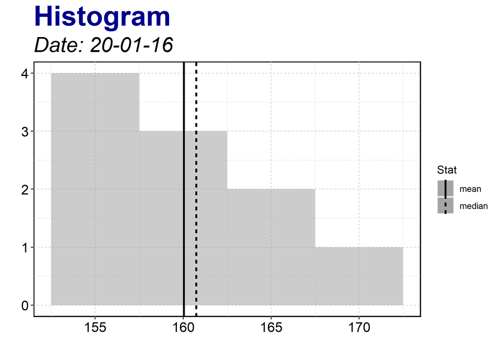

Fig 2: Demography plots

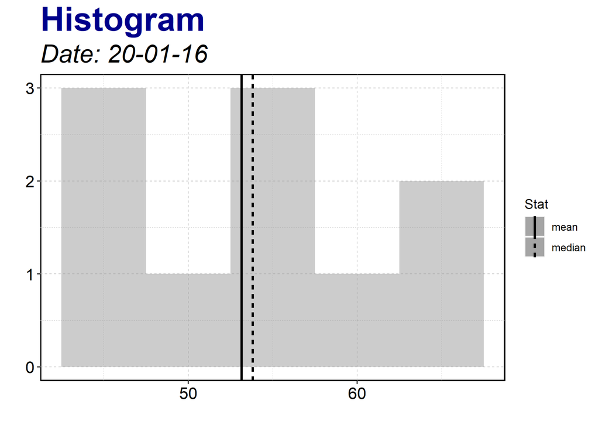

Fig 2: Demography plots

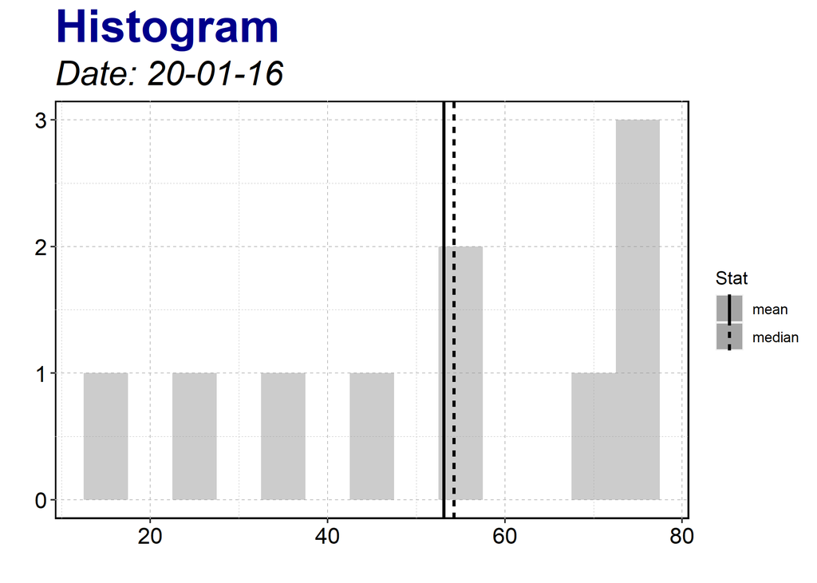

Fig 2: Demography plots

```r
demographyOutputFolder <- popWorkflow$demographyPlot$output$demographyPlot
demographyPlots <- list.files(demographyOutputFolder)
```

You can also access to the complete version of results as a `.RData` output, which allows to further customize or modify the results:

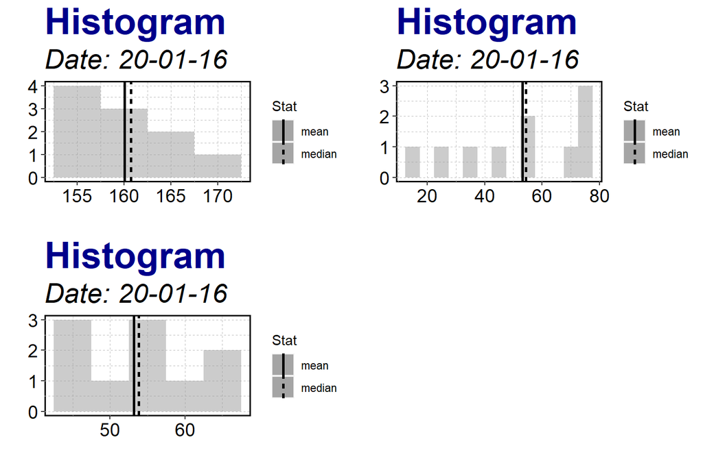

Customized results

```r
load(popWorkflow$demographyPlot$output$demographyResults)
gridExtra::grid.arrange(grobs = demographyPlot, ncol = 2)
```